# Modeling and prediction for movies

## Setup

### Load packages

```r
library(ggplot2)
library(dplyr)
library(statsr)
library(GGally)
```

## Part 1: Data

The data set is comprised of 651 observations provided by Rotten Tomatoes and IMDB on movies produced and released before 2016. Data consists of Movie details with public and critic ratings. Data is collected by random sampling method. So, as it is purely observational data, it can be analysed to establish associations between explanatory and response variables, to arrive at correlation statements.

This is an analysis on observations and there is no random assignment, not experimental data to derive causations.

So, this observational data can only be used to make generalized statements, not causation statements.

Load the data into R

```r
load("movies.Rdata")
```

About the data:

```r
nrow(movies)
```

```
## [1] 651
```

```r
ncol(movies)
```

```
## [1] 32
```

There are 651 observations(rows) on 32 variables(columns) in the data set.

The dataset is supposed to contain data collected till 2016. Let us check

```r
  summary(movies$thtr_rel_year)
```

```
##    Min. 1st Qu.  Median    Mean 3rd Qu.    Max.
##    1970    1990    2000    1998    2007    2014
```

The dataset has information of film released from 1970 till 2014.

We will see the summary info on the dataset to get an overview

```r
#summary(movies)
```

As a first step, let us clear the NAs from variables of interest and create a new dataset

```r
movies_cl <- movies[!(is.na(movies$genre)|is.na(movies$runtime)|is.na(movies$imdb_rating)|is.na(movies$critics_score)|is.na(movies$mpaa_rating)|is.na(movies$top200_box)|is.na(movies$best_pic_nom)|is.na(movies$best_pic_win)|is.na(movies$best_actor_win)|is.na(movies$best_actress_win)|is.na(movies$best_dir_win)),]
```

## Part 2: Research question

As per the researcher’s understanding and perspective, a movie’s popularity depends on the genre of the movie, ratings/score by mpaa, imdb and critics, runtime and awards won by movie team (wins and nominations by actor, actress and director) which is available in the dataset.

The researcher would like to explore how the variables of interest- genre, mpaa_rating, imdb_rating, critics_score, top200_boxoffice, runtime and award wins by movie team -> would influence the audience score, which decides the popularity of the movie.

## Part 3: Exploratory data analysis

Let us start our analysis with identifying the explanatory and response variables. Response variable -> audience_score Explanatory variables -> genre, runtime, critics_score, imdb_rating, mpaa_rating, top200_box, best_pic_nom, best_pic_win, best_actor_win, best_actress_win, best_dir_win

First, we will have to see the distribution of response variable, audience_score

```r
summary(movies$audience_score)
```

```
##    Min. 1st Qu.  Median    Mean 3rd Qu.    Max.
##   11.00   46.00   65.00   62.36   80.00   97.00
```

```r
sum(movies$audience_score<40)
```

```
## [1] 106
```

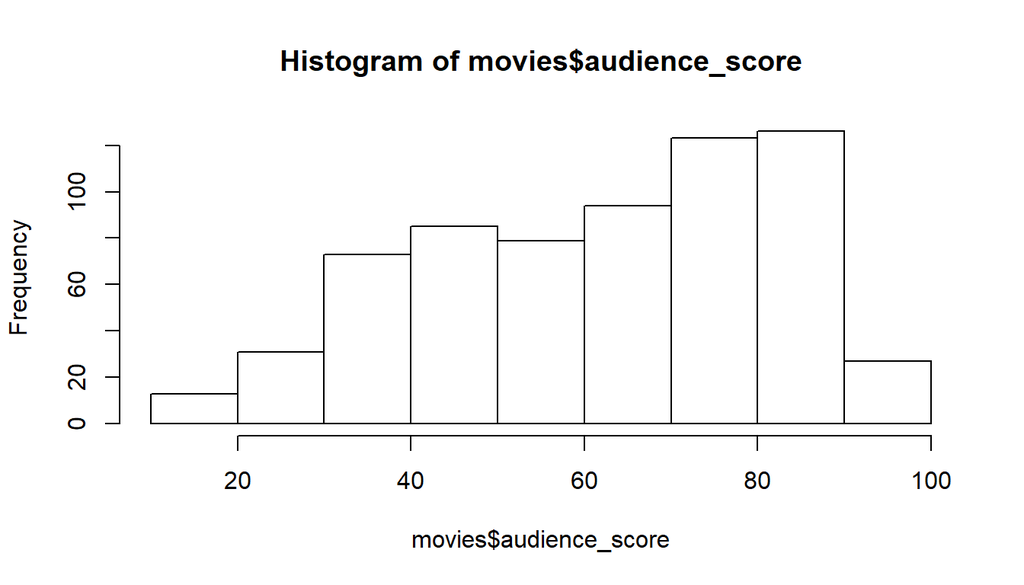

```r
hist(movies$audience_score)
```

From the summary data, we can observe that 25% of audience provide a score above 80 for 100. Also, 106 audience scores are below 40. A very slight left skew suggests that audience score the movies highly.

We can actually take a look at the relationships between all rating variables (mpaa_rating, critics_score, top200_box and imdb_rating) and genre and runtime that the researcher thinks are significant in deciding the audience_score.

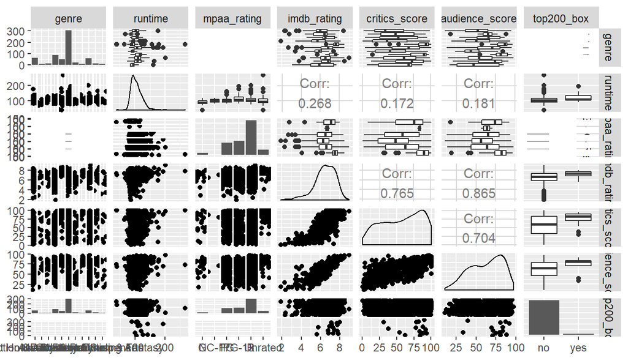

```r
ggpairs(movies_cl,columns=c(3,4,5,13,16,18,24),upper=list(continuous = "cor"),lower=list(combo=wrap("dot")))
```

The above ggpair plot shows how the variables that are used for our research are correlated (check the correlation value of 17.2% between critics_score and runtime on the top rows)- runtime, imdb_rating and critics_score, So we do not consider them for our model

## Part 4: Modeling

We design a model using the rest of the research variables -genre, mpaa_rating, best_pic_nom, best_pic_win,best_actor_win, best_actress_win, best_dir_win, top200_box using lm command

```r
movies_full <- lm(audience_score ~ mpaa_rating+ genre + best_pic_nom + best_pic_win + best_actor_win +
best_actress_win + best_dir_win +  top200_box, data = movies_cl)
summary(movies_full)
```

```
##
## Call:
## lm(formula = audience_score ~ mpaa_rating + genre + best_pic_nom +
##     best_pic_win + best_actor_win + best_actress_win + best_dir_win +
##     top200_box, data = movies_cl)
##
## Residuals:
##     Min      1Q  Median      3Q     Max
## -51.025 -12.714   1.866  13.068  39.523
##
## Coefficients:
##                                Estimate Std. Error t value Pr(>|t|)
## (Intercept)                     60.3272     4.9075  12.293  < 2e-16 ***
## mpaa_ratingNC-17                -7.6950    13.3743  -0.575  0.56525
## mpaa_ratingPG                   -7.5638     4.8432  -1.562  0.11886
## mpaa_ratingPG-13               -12.0566     4.9250  -2.448  0.01464 *
## mpaa_ratingR                    -6.8756     4.8066  -1.430  0.15308
## mpaa_ratingUnrated              -1.9846     5.4893  -0.362  0.71782
## genreAnimation                   4.8689     6.8993   0.706  0.48063
## genreArt House & International   9.6620     5.3245   1.815  0.07006 .
## genreComedy                      0.5006     2.9350   0.171  0.86461
## genreDocumentary                26.6830     3.8356   6.957 8.78e-12 ***
## genreDrama                      11.2620     2.5137   4.480 8.86e-06 ***
## genreHorror                     -8.2863     4.3756  -1.894  0.05872 .
## genreMusical & Performing Arts  26.0033     5.5869   4.654 3.97e-06 ***
## genreMystery & Suspense          2.1029     3.2934   0.639  0.52336
## genreOther                      10.1676     4.9745   2.044  0.04137 *
## genreScience Fiction & Fantasy  -4.7906     6.2764  -0.763  0.44559
## best_pic_nomyes                 21.9480     4.4885   4.890 1.28e-06 ***
## best_pic_winyes                 -1.8384     8.0325  -0.229  0.81904
## best_actor_winyes               -0.7884     2.0629  -0.382  0.70248
## best_actress_winyes             -1.2859     2.3108  -0.556  0.57808
## best_dir_winyes                  6.7925     2.9781   2.281  0.02289 *
## top200_boxyes                   13.6286     4.7402   2.875  0.00418 **
## ---
## Signif. codes:  0 '***' 0.001 '**' 0.01 '*' 0.05 '.' 0.1 ' ' 1
##
## Residual standard error: 17.6 on 628 degrees of freedom
## Multiple R-squared:  0.2675, Adjusted R-squared:  0.2431
## F-statistic: 10.92 on 21 and 628 DF,  p-value: < 2.2e-16
```

```r
movies_ideal <- lm(audience_score ~  best_pic_nom + best_dir_win + top200_box, data = movies_cl)
summary(movies_ideal)
```

```
##
## Call:
## lm(formula = audience_score ~ best_pic_nom + best_dir_win + top200_box,
##     data = movies_cl)
##
## Residuals:
##     Min      1Q  Median      3Q     Max
## -50.048 -15.746   2.952  16.952  34.952
##
## Coefficients:
##                 Estimate Std. Error t value Pr(>|t|)
## (Intercept)       61.048      0.815  74.908  < 2e-16 ***
## best_pic_nomyes   22.027      4.344   5.070 5.19e-07 ***
## best_dir_winyes    4.930      3.152   1.564   0.1183
## top200_boxyes      9.891      5.173   1.912   0.0563 .
## ---
## Signif. codes:  0 '***' 0.001 '**' 0.01 '*' 0.05 '.' 0.1 ' ' 1
##
## Residual standard error: 19.72 on 646 degrees of freedom
## Multiple R-squared:  0.05441,    Adjusted R-squared:  0.05002
## F-statistic: 12.39 on 3 and 646 DF,  p-value: 6.899e-08
```

The reason I chose backwards elimination with adjusted R squared is that backwards elimination is more widly used and adjusted R squared can make more reliable predictions than p-value.

Now we will try a different model selection method: backwards elimination with adjusted R squared, commonly used to make more accurate predictions.

Create a new model, `movies_m1`, where you remove `best_pic_nom` from the list of explanatory variables. Check out the adjusted $R^2$ of this new model and compare it to the adjusted $R^2$ (0.05002) of the ideal model “movies_ideal”.

```r
movies_m1 <- lm(audience_score ~   best_dir_win + top200_box, data = movies_cl)
summary(movies_m1)$adj.r.squared
```

```
## [1] 0.01373719
```

```r
movies_m2 <- lm(audience_score ~  best_pic_nom + best_dir_win, data = movies_cl)
summary(movies_m2)$adj.r.squared
```

```
## [1] 0.0461169
```

```r
movies_m3 <- lm(audience_score ~  best_dir_win + top200_box, data = movies_cl)
summary(movies_m3)$adj.r.squared
```

```
## [1] 0.01373719
```

So, the ideal model would be considered as the parsimonious model for this dataset, which has the minimal set of explanatory variables in best predicting the response variable.

Diagnostics of the model: 1) Linear relationship check

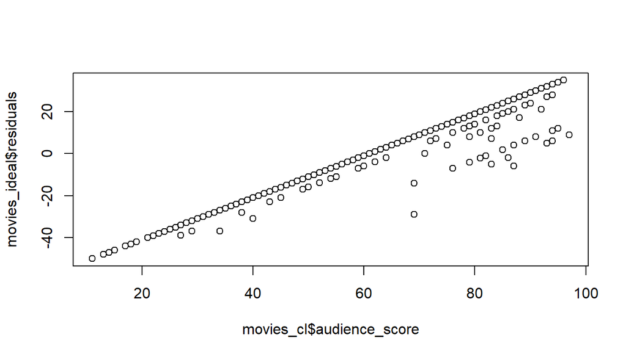

```r
plot(movies_ideal$residuals~movies_cl$audience_score)
```

2. NOrmal residuals with mean 0

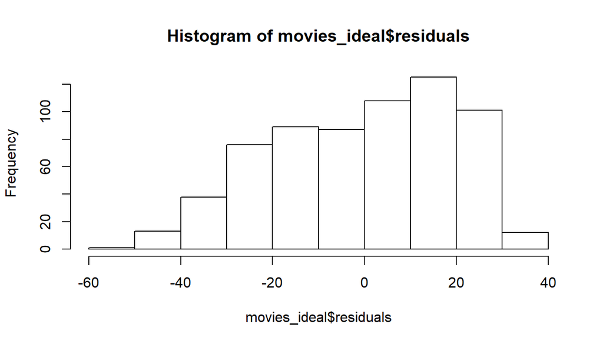

```r
hist(movies_ideal$residuals)
```

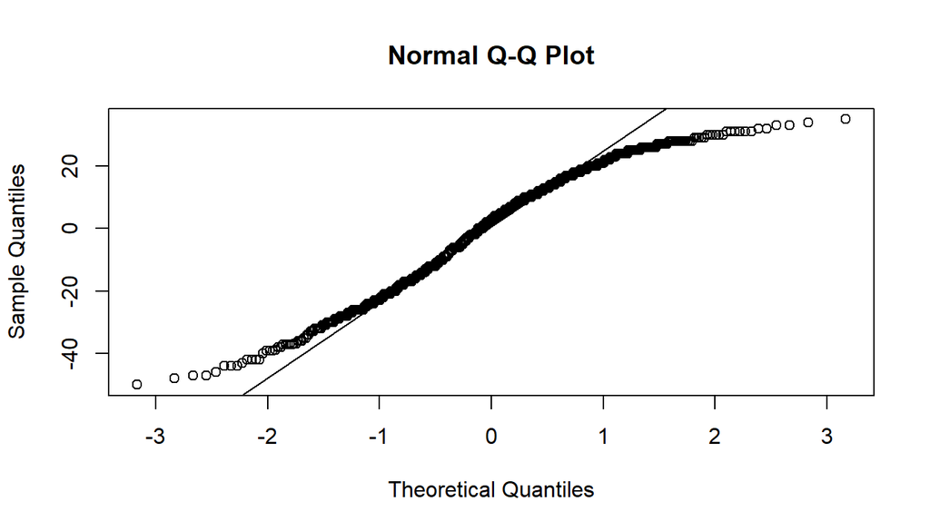

```r
qqnorm(movies_ideal$residuals)
qqline(movies_ideal$residuals)
```

The histogram and the probability plot shows slight left skew.

3. Constant variability of residuals

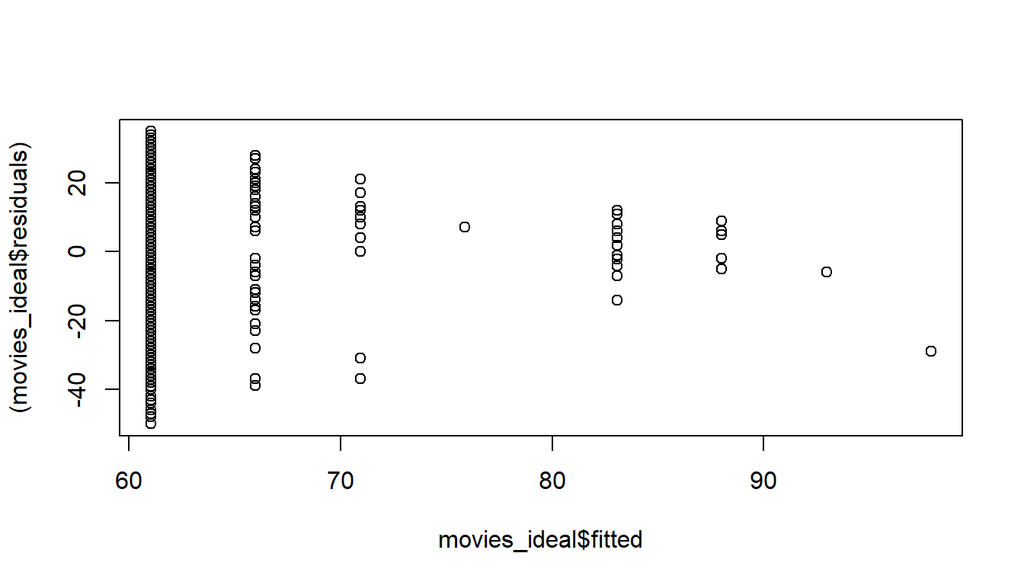

```r
plot((movies_ideal$residuals)~movies_ideal$fitted)
```

The residuals show constant variablity.

4. independence

The data is completely random and independent of each other.

## Part 5: Prediction

Suppose we want to use the model we created, `movies_ideal` to predict the audience_score of a movie, We can calculate the predicted value in R.

First, we need to create a new data frame for this movie

```r
newmovie <- data.frame(best_pic_nom = "yes", best_dir_win = "no", top200_box = "yes")
```

We can also construct a prediction interval around this prediction, which will provide a measure of uncertainty around the prediction.

```r
predict(movies_ideal, newmovie, interval = "prediction", level = 0.95)
```

```
##        fit     lwr      upr
## 1 92.96566 52.2596 133.6717
```

Hence, the model predicts, with 95% confidence, that has got best pic nomination and ‘no’ best director win and listed in top200 of box office is expected to have an audience score between 52.26 and 133.68

Let us check this with an example from the dataset that suits these conditions -> best_pic_nom = “yes”, best_dir_win = “no”, top200_box = “yes”

```r
movies_chk <- movies_cl %>%
filter(best_pic_nom == "yes"& best_dir_win == "no"& top200_box == "yes") %>%
select(audience_score,best_pic_nom,best_dir_win,top200_box )

movies_chk
```

```
## # A tibble: 1 x 4
##   audience_score best_pic_nom best_dir_win top200_box
##            <dbl>       <fctr>       <fctr>     <fctr>
## 1             87          yes           no        yes
```

The model predicted audience score (92.96) is pretty much close to the already existing sample data (87). So the model has done correct prediction. * * *

## Part 6: Conclusion

As per the researcher’s choice of variables for the linear regression model, the ideal model that was predicted is the one involving best pic nomination, best director win and top200 in box office. The significant predictors, which the researcher thought would decide the audience_score were correlated, so we had to eliminate those variables and identify the full model and then the ideal model using adjusted R squared method. If there were more numerical variables in the dataset, than the categorical variables, a better model could have been modelled.